# Study 1 — Emotional valence and intuitive coherence judgments

- Show All Code
- Hide All Code
- View Source

Accuracy, response time, confidence, and gaze in the Dyads-of-Triads task

Author

Przemysław Marcowski

Published

July 16, 2026

```r
e1 <- readRDS(here("data/processed/prepared/exp1.Rds"))

# One row per participant x trial for the behavioral measures.
behav <- e1 %>%
  group_by(participant_id, triad_solvable, affect, trial) %>%
  summarise(accuracy = first(accuracy), rt = first(accuracy_rt),
            confidence = first(confidence), .groups = "drop")
```

# 1 Overview

Study 1 manipulated the **emotional valence** of the solvable triad’s solution (Negative, Neutral, Positive) as a source of *semantic* processing fluency. We test whether valence shapes the subjective experience of an intuitive coherence judgment — response time (H2) and confidence (H3) — and its attentional signature (gaze preference, H4), while objective accuracy (H1) stays at ceiling. The analysed sample is *N* = 39.

**NoteModel specification**

Behavioral outcomes are modelled with `glmmTMB` — binomial for accuracy, Gaussian for log-RT and confidence — with affect as a fixed effect and random intercepts for participants and trial positions. The maximal by-participant affect slope is singular and is not retained. Omnibus tests are Wald χ² (`car::Anova`); follow-up pairwise contrasts are FDR-adjusted estimated marginal means with Cohen’s *d*.

```r
# Standardised difference for a Gaussian LMM contrast (estimate / residual SD).
cohen_d <- function(model, contrasts) {
  emm_df(contrasts) %>% mutate(d = estimate / sigma(model))
}
```

## 1.1 Accuracy (H1)

```r
acc_data <- behav %>% filter(!is.na(accuracy))

# Above-chance detection, per valence.
acc_tests <- acc_data %>%
  group_by(affect) %>%
  summarise(successes = sum(accuracy), trials = n(), .groups = "drop") %>%
  rowwise() %>%
  mutate(prop = successes / trials,
         ci = list(binom.test(successes, trials, 0.5, "greater")$conf.int),
         ci_low = ci[1], p_value = binom.test(successes, trials, 0.5, "greater")$p.value,
         sig = sig_stars(p_value)) %>%
  ungroup() %>% select(affect, successes, trials, prop, ci_low, p_value, sig)

acc_model <- glmmTMB(accuracy ~ affect + (1 | participant_id) + (1 | trial),
                     data = acc_data, family = binomial)
acc_omnibus <- car::Anova(acc_model)
write_csv(acc_tests, file.path(out_dir, "accuracy_tests.csv"))
write_csv(rownames_to_column(as.data.frame(acc_omnibus), "term"), file.path(out_dir, "accuracy_effects.csv"))

knitr::kable(acc_tests, digits = 3, caption = "Above-chance accuracy by valence (one-sided binomial tests).")
```

Above-chance accuracy by valence (one-sided binomial tests).

| affect | successes | trials | prop | ci_low | p_value | sig |
| --- | --- | --- | --- | --- | --- | --- |
| Negative | 136 | 151 | 0.901 | 0.851 | 0 | *** |
| Neutral | 150 | 159 | 0.943 | 0.903 | 0 | *** |
| Positive | 144 | 156 | 0.923 | 0.878 | 0 | *** |

Accuracy was uniformly high (all conditions > 90%, all *p*s < .001) and unaffected by valence (χ²(2) = 1.63, p = 0.443). This ceiling constrains inference about the null effect on objective performance.

## 1.2 Response time (H2)

```r
rt_data <- behav %>% filter(!is.na(rt)) %>% mutate(log_rt = log(rt))
rt_model <- glmmTMB(log_rt ~ affect + (1 | participant_id) + (1 | trial), data = rt_data)
rt_omnibus <- car::Anova(rt_model)
rt_emm <- emmeans(rt_model, ~ affect)
rt_contrasts <- contrast(rt_emm, "pairwise", adjust = "fdr")
rt_table <- cohen_d(rt_model, summary(rt_contrasts, infer = TRUE))
write_csv(rownames_to_column(as.data.frame(rt_omnibus), "term"), file.path(out_dir, "rt_effects.csv"))
write_csv(emm_df(rt_emm), file.path(out_dir, "rt_means.csv"))
write_csv(rt_table, file.path(out_dir, "rt_contrasts.csv"))
```

```r
# The maximal by-participant slope model is singular, so the reported model uses
# random intercepts.
rt_slope_model <- glmmTMB(log_rt ~ affect + (affect | participant_id) + (1 | trial), data = rt_data)
performance::check_singularity(rt_slope_model)
```

```
[1] TRUE
```

Valence affected response speed (χ²(2) = 17.96, p < .001): positive-solution triads were judged fastest, significantly faster than negative and neutral ones. The maximal model with a by-participant valence slope is singular, so the reported model retains random intercepts for participants and trial positions.

```r
knitr::kable(rt_table %>% select(contrast, estimate, SE, lower.CL, upper.CL, p.value, d),
             digits = 3, caption = "Study 1 log-RT pairwise contrasts (FDR-adjusted) with Cohen's d.")
```

Study 1 log-RT pairwise contrasts (FDR-adjusted) with Cohen’s d.

| contrast | estimate | SE | lower.CL | upper.CL | p.value | d |
| --- | --- | --- | --- | --- | --- | --- |
| Negative - Neutral | -0.017 | 0.03 | -0.089 | 0.055 | 0.566 | -0.066 |
| Negative - Positive | 0.100 | 0.03 | 0.028 | 0.172 | 0.001 | 0.380 |
| Neutral - Positive | 0.117 | 0.03 | 0.046 | 0.188 | 0.000 | 0.446 |

## 1.3 Confidence (H3)

```r
conf_data <- behav %>% filter(!is.na(confidence))
conf_model <- glmmTMB(confidence ~ affect + (1 | participant_id) + (1 | trial), data = conf_data)
conf_omnibus <- car::Anova(conf_model)
conf_emm <- emmeans(conf_model, ~ affect)
conf_contrasts <- contrast(conf_emm, "pairwise", adjust = "fdr")
conf_table <- cohen_d(conf_model, summary(conf_contrasts, infer = TRUE))
write_csv(rownames_to_column(as.data.frame(conf_omnibus), "term"), file.path(out_dir, "confidence_effects.csv"))
write_csv(emm_df(conf_emm), file.path(out_dir, "confidence_means.csv"))
write_csv(conf_table, file.path(out_dir, "confidence_contrasts.csv"))
```

Confidence also varied with valence (χ²(2) = 13.70, p = 0.001): positive-solution triads drew the highest confidence.

```r
knitr::kable(conf_table %>% select(contrast, estimate, SE, lower.CL, upper.CL, p.value, d),
             digits = 3, caption = "Study 1 confidence pairwise contrasts (FDR-adjusted) with Cohen's d.")
```

Study 1 confidence pairwise contrasts (FDR-adjusted) with Cohen’s d.

| contrast | estimate | SE | lower.CL | upper.CL | p.value | d |
| --- | --- | --- | --- | --- | --- | --- |
| Negative - Neutral | 0.105 | 0.221 | -0.424 | 0.635 | 0.634 | 0.055 |
| Negative - Positive | -0.648 | 0.224 | -1.183 | -0.112 | 0.006 | -0.338 |
| Neutral - Positive | -0.753 | 0.219 | -1.276 | -0.230 | 0.002 | -0.393 |

## 1.4 Gaze preference (H4)

```r
tsd <- make_time_sequence_data(e1, time_bin_size = bin_size, aois = c("Solvable", "Nonsolvable"),
                               predictor_columns = "affect", summarize_by = c("participant_id", "trial"))
preference <- tsd %>%
  pivot_wider(id_cols = c(participant_id, trial, affect, Time, ot1:ot4),
              names_from = AOI, values_from = SamplesInAOI, names_prefix = "looks_") %>%
  mutate(total = looks_Solvable + looks_Nonsolvable,
         preference = (looks_Solvable - looks_Nonsolvable) / total) %>%
  filter(total > 0)

# The correlated time-slope block can exceed the default evaluation limits, so the
# optimizer budget is enlarged.
gca <- glmmTMB(preference ~ affect * (ot1 + ot2 + ot3 + ot4) +
                 (1 + ot1 + ot2 + ot3 + ot4 | participant_id) + (1 | trial),
               data = preference, weights = total,
               control = glmmTMBControl(optCtrl = list(iter.max = 2000, eval.max = 2000)))
gca_omnibus <- car::Anova(gca)
gca_emm <- emmeans(gca, ~ affect)
gca_contrasts <- cohen_d(gca, summary(contrast(gca_emm, "pairwise", adjust = "fdr"), infer = TRUE))
write_csv(rownames_to_column(as.data.frame(gca_omnibus), "term"), file.path(out_dir, "preference_effects.csv"))
write_csv(emm_df(gca_emm), file.path(out_dir, "preference_means.csv"))
write_csv(gca_contrasts, file.path(out_dir, "preference_contrasts.csv"))
```

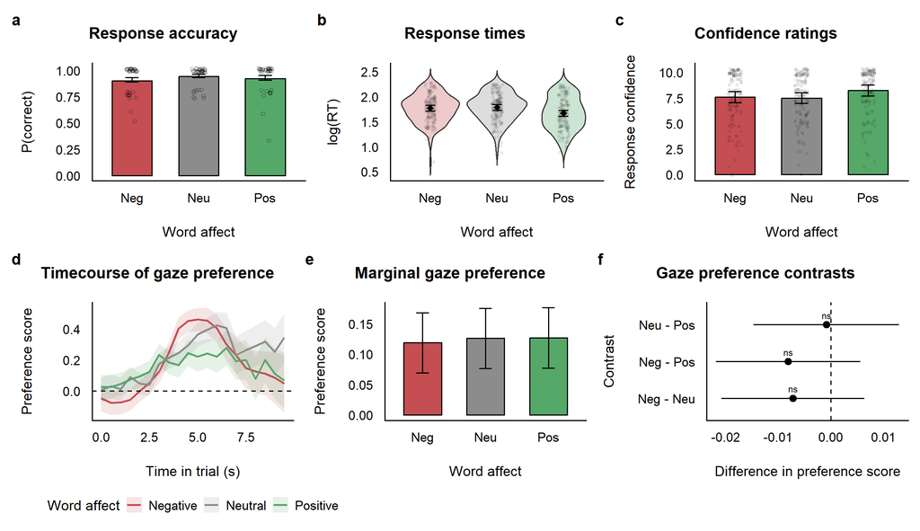

```r
# Six-panel layout (a–f).
affect_abbrev <- c(Negative = "Neg", Neutral = "Neu", Positive = "Pos")

p_acc <- acc_data %>% group_by(participant_id, affect) %>% summarise(prob = mean(accuracy), .groups = "drop") %>%
  ggplot(aes(affect, prob, fill = affect)) +
  geom_col(data = acc_tests, aes(y = prop), width = 0.6, colour = "black") +
  geom_jitter(width = 0.1, alpha = 0.3, shape = 1) +
  stat_summary(fun.data = mean_se, geom = "errorbar", width = 0.2) +
  scale_fill_manual(values = affect_colours, guide = "none") +
  scale_x_discrete(labels = affect_abbrev) +
  labs(title = "Response accuracy", x = "Word affect", y = "P(correct)")

p_rt <- ggplot(rt_data, aes(affect, log_rt)) +
  geom_violin(aes(fill = affect), alpha = 0.3, trim = FALSE) +
  geom_jitter(width = 0.08, alpha = 0.15, shape = 1, size = 0.8) +
  geom_errorbar(data = emm_df(rt_emm), aes(y = emmean, ymin = lower.CL, ymax = upper.CL), width = 0.15) +
  geom_point(data = emm_df(rt_emm), aes(y = emmean), size = 3, shape = 18) +
  scale_fill_manual(values = affect_colours, guide = "none") +
  scale_x_discrete(labels = affect_abbrev) +
  labs(title = "Response times", x = "Word affect", y = "log(RT)")

p_conf <- ggplot(emm_df(conf_emm), aes(affect, emmean, fill = affect)) +
  geom_col(width = 0.6, colour = "black") +
  geom_jitter(data = conf_data, aes(affect, confidence), inherit.aes = FALSE,
              width = 0.1, alpha = 0.15, shape = 1, size = 0.8) +
  geom_errorbar(aes(ymin = lower.CL, ymax = upper.CL), width = 0.2) +
  scale_fill_manual(values = affect_colours, guide = "none") +
  scale_x_discrete(labels = affect_abbrev) +
  labs(title = "Confidence ratings", x = "Word affect", y = "Response confidence")

p_time <- ggplot(preference, aes(Time, preference, colour = affect, fill = affect)) +
  stat_summary(geom = "ribbon", fun.data = mean_se, colour = NA, alpha = 0.15) +
  stat_summary(geom = "line", fun = mean, linewidth = 1) +
  geom_hline(yintercept = 0, linetype = "dashed") +
  scale_colour_manual(values = affect_colours) + scale_fill_manual(values = affect_colours) +
  labs(title = "Timecourse of gaze preference", x = "Time in trial (s)", y = "Preference score",
       colour = "Word affect", fill = "Word affect")

p_pref <- ggplot(emm_df(gca_emm), aes(affect, emmean, fill = affect)) +
  geom_col(width = 0.6, colour = "black") +
  geom_errorbar(aes(ymin = lower.CL, ymax = upper.CL), width = 0.2) +
  scale_fill_manual(values = affect_colours, guide = "none") +
  scale_x_discrete(labels = affect_abbrev) +
  labs(title = "Marginal gaze preference", x = "Word affect", y = "Preference score")

contr_plot <- gca_contrasts %>%
  mutate(pair = contrast %>% gsub("Negative", "Neg", x = .) %>% gsub("Neutral", "Neu", x = .) %>%
           gsub("Positive", "Pos", x = .),
         sig = as.character(sig_stars(p.value)))
p_contr <- ggplot(contr_plot, aes(estimate, pair)) +
  geom_vline(xintercept = 0, linetype = "dashed") +
  geom_pointrange(aes(xmin = lower.CL, xmax = upper.CL)) +
  geom_text(aes(label = sig), vjust = -0.9, size = 3.2) +
  labs(title = "Gaze preference contrasts", x = "Difference in preference score", y = "Contrast")

figure <- (p_acc | p_rt | p_conf) / (p_time | p_pref | p_contr) + plot_annotation(tag_levels = "a")
ggsave(file.path(out_dir, "figure.png"), figure, width = 13, height = 7.5, dpi = 300)
figure
```

## 1.5 Correlations: inspection time vs. accuracy and confidence

```r
inspect <- e1 %>%
  group_by(participant_id, affect, trial) %>%
  summarise(inspection = sum(Solvable, na.rm = TRUE),
            accuracy = first(accuracy), confidence = first(confidence), .groups = "drop")

# Confidence: repeated-measures correlation (within participant). Accuracy: mixed logistic.
conf_rm <- inspect %>% filter(!is.na(confidence)) %>% mutate(participant_id = factor(participant_id)) %>%
  rmcorr(participant_id, inspection, confidence, dataset = .)
acc_glmm <- glmmTMB(accuracy ~ scale(inspection) + (1 | participant_id),
                    data = inspect %>% filter(!is.na(accuracy)), family = binomial)
acc_glmm_p <- car::Anova(acc_glmm)[["Pr(>Chisq)"]][1]
correlations <- tibble(
  analysis = c("confidence ~ inspection (rmcorr)", "accuracy ~ inspection (mixed logistic)"),
  estimate = c(conf_rm$r, fixef(acc_glmm)$cond[["scale(inspection)"]]),
  ci_low = c(conf_rm$CI[1], NA), ci_high = c(conf_rm$CI[2], NA),
  p_value = c(conf_rm$p, acc_glmm_p))
write_csv(correlations, file.path(out_dir, "correlations.csv"))
```

Longer inspection of the solvable triad was associated with **lower** confidence (rmcorr *r* = -0.18, *p* < .001), consistent with a decision-difficulty account. Inspection time did not predict accuracy (mixed logistic, *p* = 0.226).

## 1.6 Supplementary tables

```r
# Raw condition-level descriptives complementing the model-based estimates above.
descriptives <- behav %>%
  pivot_longer(c(accuracy, rt, confidence), names_to = "outcome") %>%
  filter(!is.na(value)) %>%
  group_by(outcome, affect) %>%
  summarise(n = n(), mean = mean(value), sd = sd(value), se = sd / sqrt(n), .groups = "drop")
write_csv(descriptives, file.path(out_dir, "descriptives.csv"))

# Specification and fit diagnostics for every model reported above.
re_sd <- function(m, group) {
  v <- VarCorr(m)$cond[[group]]
  if (is.null(v)) NA_real_ else attr(v, "stddev")[[1]]
}
models <- list(accuracy = acc_model, rt = rt_model, confidence = conf_model, gaze_gca = gca)
model_summary <- imap_dfr(models, \(m, name) tibble(
  model = name,
  formula = deparse1(formula(m)),
  family = family(m)$family,
  n_obs = nobs(m),
  n_participants = n_distinct(model.frame(m)$participant_id),
  sd_participant_intercept = re_sd(m, "participant_id"),
  sd_trial_intercept = re_sd(m, "trial"),
  converged = isTRUE(performance::check_convergence(m)),
  singular_fit = isTRUE(performance::check_singularity(m))))
write_csv(model_summary, file.path(out_dir, "model_summary.csv"))
knitr::kable(model_summary, digits = 3,
             caption = "Model specifications and fit diagnostics; a singular fit reflects a variance component estimated at zero (see the SD columns).")
```

Model specifications and fit diagnostics; a singular fit reflects a variance component estimated at zero (see the SD columns).

| model | formula | family | n_obs | n_participants | sd_participant_intercept | sd_trial_intercept | converged | singular_fit |
| --- | --- | --- | --- | --- | --- | --- | --- | --- |
| accuracy | accuracy ~ affect + (1 \| participant_id) + (1 \| trial) | binomial | 466 | 39 | 0.631 | 0.452 | TRUE | FALSE |
| rt | log_rt ~ affect + (1 \| participant_id) + (1 \| trial) | gaussian | 466 | 39 | 0.138 | 0.000 | TRUE | TRUE |
| confidence | confidence ~ affect + (1 \| participant_id) + (1 \| trial) | gaussian | 458 | 39 | 1.373 | 0.000 | TRUE | TRUE |
| gaze_gca | preference ~ affect * (ot1 + ot2 + ot3 + ot4) + (1 + ot1 + ot2 + ot3 + ot4 \| participant_id) + (1 \| trial) | gaussian | 7005 | 39 | 0.313 | 0.053 | TRUE | FALSE |

```r
knitr::kable(descriptives, digits = 3, caption = "Raw condition-level descriptives (means, SD, SE).")
```

Raw condition-level descriptives (means, SD, SE).

| outcome | affect | n | mean | sd | se |
| --- | --- | --- | --- | --- | --- |
| accuracy | Negative | 151 | 0.901 | 0.300 | 0.024 |
| accuracy | Neutral | 159 | 0.943 | 0.232 | 0.018 |
| accuracy | Positive | 156 | 0.923 | 0.267 | 0.021 |
| confidence | Negative | 147 | 7.599 | 2.496 | 0.206 |
| confidence | Neutral | 159 | 7.516 | 2.335 | 0.185 |
| confidence | Positive | 152 | 8.204 | 2.230 | 0.181 |
| rt | Negative | 151 | 6.067 | 1.611 | 0.131 |
| rt | Neutral | 159 | 6.167 | 1.645 | 0.130 |
| rt | Positive | 156 | 5.586 | 1.797 | 0.144 |